# APEX Tutorial

Predicting transcriptional states from plasma cfChIP-seq

19 January 2026

# 1 Overview

APEX (Associating Plasma Epigenomics with eXpression) infers genome-wide tumor gene expression from plasma cfChIP-seq by integrating positional coverage and fragment-derived features from histone mark–enriched DNA (e.g., H3K4me3 and H3K36me3) using pretrained models.

This vignette demonstrates an example analysis in which cfChIP-seq targeting H3K4me3 and H3K36me3 was performed on baseline plasma samples from patients with metastatic bladder cancer treated with enfortumab vedotin, a NECTIN4-targeting antibody–drug conjugate. Patients are stratified into responders and non-responders based on clinical outcome. The vignette walks through a representative APEX workflow for inferring genome-wide gene expression from plasma epigenomic profiles, followed by downstream gene-level and gene-set–level differential expression analyses and visualization. We test the hypothesis that higher APEX-inferred *NECTIN4* expression is associated with better response to EV. All data used in this vignette have been de-identified.

# 2 Getting started

## 2.1 Required input files

The APEX R package expects fragment-level files that include fragment coordinates plus fragment-derived covariates (GC, fragment length, end motifs). We recommend generating these files from raw FASTQ or BAM files using the streamlined Nextflow pipeline, SNAP, publicly available at https://github.com/prc992/SNAP/. The SNAP pipeline expects FASTQ or BAM files and outputs the APEX-compatible fragment files in the motifs folder. Importantly, please use hg19 reference genome as APEX coordinates are hg19-based.

The fragment BED-like file is formatted into the following 8 columns:

1. chromosome
2. start
3. end
4. strand (optional)
5. fragment length
6. fragment GC content
7. 5’ end motif (read 1)
8. 5’ end motif (read 2)

For this vignette, we provide processed .bed files for download and test-use with the R package. We also include processed results in the vignette_results.rds file, which contains:

- a `manifest`
- per-sample QC summary
- a per-sample APEX result object (single-sample run)
- a cohort-level APEX matrix (`genes × samples`)

```r
#Load pre-processed vignette results
ext <- readRDS(system.file("resources/vignette_results.rds", package = "apex"))

#Assign vignette results to objects
manifest    <- ext$manifest
qc          <- ext$qc
apex_single <- ext$apex_single
apex_mat    <- ext$apex_mat
```

# 3 Install and load packages

APEX is an R package available from GitHub. The code below installs the required dependency, installs APEX if needed, and loads the package.

```r
# Install remotes for GitHub installation
if (!requireNamespace("remotes", quietly = TRUE)) {
  install.packages("remotes")
}

# Install APEX from GitHub (if not already installed)
if (!requireNamespace("apex", quietly = TRUE)) {
  remotes::install_github("Baca-Lab/APEX", build_vignettes = TRUE, dependencies = TRUE)
}

# Load the package
library(apex)
```

# 4 Preparing a manifest

A minimal manifest is a `data.frame` with one row per sample containing the following information by column: Column 1: Sample ID Column 2: Path to H3K4me3 fragment file Column 3: Path to H3K27ac fragment file Column 4: Path to H3K36me3 fragment file Column 5: two-level variable for comparison

In these examples, we will use the manifest provided in the vignette data file. The phenotype of interest in this example is clinical response to enfortumab vedotin.

```r
#manifest <- data.frame(
#  sample_id = sample_id,
#  frag_k4   = frag_k4,
#  frag_k27  = NA,
#  frag_k36  = frag_k36,
#  response  = groups
#)

print(head(manifest))
```

```
#>      sample_id                              frag_k4 frag_k27
#> 1 RN_BLCA_1021   RN_BLCA_1021_K4_4NMER_bp_motif.bed       NA
#> 2 RN_BLCA_1040   RN_BLCA_1040_K4_4NMER_bp_motif.bed       NA
#> 3  RN_BLCA_183 RN_BLCA_183_K4_TF_4NMER_bp_motif.bed       NA
#> 4  RN_BLCA_372    RN_BLCA_372_K4_4NMER_bp_motif.bed       NA
#> 5  RN_BLCA_374    RN_BLCA_374_K4_4NMER_bp_motif.bed       NA
#> 6  RN_BLCA_375    RN_BLCA_375_K4_4NMER_bp_motif.bed       NA
#>                                frag_k36        groups
#> 1   RN_BLCA_1021_K36_4NMER_bp_motif.bed Non-responder
#> 2   RN_BLCA_1040_K36_4NMER_bp_motif.bed Non-responder
#> 3 RN_BLCA_183_K36_CS_4NMER_bp_motif.bed Non-responder
#> 4    RN_BLCA_372_K36_4NMER_bp_motif.bed Non-responder
#> 5    RN_BLCA_374_K36_4NMER_bp_motif.bed     Responder
#> 6    RN_BLCA_375_K36_4NMER_bp_motif.bed Non-responder
```

# 5 Check sample quality

## 5.1 Quality control with enrichment scores and fragment number

Before feature extraction and expression inference, we recommend assessing cfChIP-seq library quality using histone mark–specific enrichment metrics. APEX reports two complementary measures per sample and mark: • Fragment number: total uniquely mapped fragments (depth/complexity proxy) • Enrichment score: signal-to-noise, comparing normalized coverage over “on-target” vs “off-target” regions

Enrichment scores are computed using predefined on-target/off-target regions derived from ChromHMM annotations from the Roadmap Epigenomics Project (see `?apex_qc` for details).

When ‘plotQC’ is set to ‘TRUE’, the function will generate boxplots and QC pass summaries for enrichment scores and fragment counts using mark-specific thresholds.

```r
#qc <- apex_qc(manifest = head(manifest), plotQC = TRUE)

print(head(qc))
```

```
#>         sample H3K4me3_enrichment H3K4me3_frag_num H3K27ac_enrichment
#> 1 RN_BLCA_1021          38.117616          6365240                 NA
#> 2 RN_BLCA_1040          89.585547          1612757                 NA
#> 3  RN_BLCA_183          35.833664           640188                 NA
#> 4  RN_BLCA_372          90.736237          1133809                 NA
#> 5  RN_BLCA_374          49.165170          1810152                 NA
#> 6  RN_BLCA_375           6.789847         14040315                 NA
#>   H3K27ac_frag_num H3K36me3_enrichment H3K36me3_frag_num
#> 1               NA            3.879283          24363397
#> 2               NA            6.437190           5893499
#> 3               NA            4.661676           2082169
#> 4               NA           16.362010           1401676
#> 5               NA            3.511140          12433610
#> 6               NA            9.855535           9320619
```

## 5.2 Practical QC thresholds

The following quality thresholds are generally recommended for optimal performance. These values should be regarded as guidelines rather than strict requirements, as acceptable results are often obtained with lower enrichment scores and fewer fragments: • H3K4me3: enrichment > 7 and > 1 million unique fragments • H3K27ac: enrichment > 7 and > 1 million unique fragments • H3K36me3: enrichment > 2 and > 2 million unique fragments.

# 6 Run APEX

Once samples pass basic QC, APEX extracts epigenomic and fragmentomic features and infers genome-wide gene expression using pretrained models.

APEX provides multiple pretrained models corresponding to the chromatin immunoprecipitation data available for a given sample:

- **H3K4me3 only**
- **H3K36me3 only**
- **H3K4me3 + H3K36me3** *(recommended use case)*
- **H3K4me3 + H3K36me3 + H3K27ac**

APEX selects the appropriate model based on the fragment files supplied.

**Note:** H3K27ac alone is not provided as a standalone model, as it performed poorly in model evaluation when used in isolation.

## 6.1 Single-sample run

A single-sample run is useful for sanity-checking runtime, output shape, and obvious file issues.

```r
#apex_single <- apex(
#  frag_file_k4  = manifest$frag_k4[1],
#  frag_file_k36 = manifest$frag_k36[1],
#  verbose = TRUE
#)

dim(apex_single)
```

```
#> [1] 18487     1
```

```r
head(apex_single)
```

```
#>             [,1]
#> A1BG    7.656140
#> A1CF    1.621209
#> A2M     2.286031
#> A2ML1   1.615101
#> A3GALT2 1.801350
#> A4GALT  3.748145
```

## 6.2 Batch run

```r
#apex_mat <- apex_batch(manifest = manifest, verbose = TRUE)

dim(apex_mat)
apex_mat[1:5, 1:5]
```

[output not shown]

# 7 Run differential expression analysis

Because APEX outputs inferred expression in a matrix format analogous to bulk RNA-seq, results can be analyzed with standard transcriptomic workflows.

`apex_diff()` performs a limma-based differential analysis to estimate log-fold changes and moderated statistics for each gene.

```r
de <- apex_diff(apex_mat, group = manifest$groups)
head(de)
```

```
#>                  gene logFC_Responder_Non.responder  AveExpr        t
#> EMX2             EMX2                      2.004643 3.930897 5.012869
#> B4GALNT4     B4GALNT4                      1.979540 3.149505 4.658378
#> CHAD             CHAD                      1.758368 3.496577 4.004104
#> C19orf33     C19orf33                      1.738769 3.859200 5.020033
#> CHRNA4         CHRNA4                      1.664253 3.330599 4.210578
#> AC011499.1 AC011499.1                      1.624728 3.069329 3.022216
#>                 P.Value adj.P.Val           B
#> EMX2       2.384535e-05 0.2203072  1.62476477
#> B4GALNT4   6.410372e-05 0.2961272  0.93857119
#> CHAD       3.900343e-04 0.4385687 -0.33774173
#> C19orf33   2.337296e-05 0.2203072  1.63854238
#> CHRNA4     2.215647e-04 0.4385687  0.06480117
#> AC011499.1 5.169753e-03 0.4559622 -2.19611589
```

## 7.1 Visualization with volcano plots

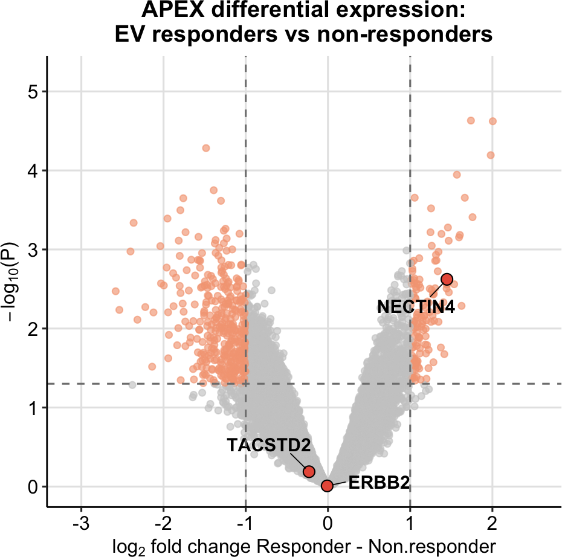

```r
apex_volcano_plot(
  de,
  highlight_genes = c("NECTIN4", "TACSTD2", "ERBB2"),
  title = "APEX differential expression:\nEV responders vs non-responders"
)
```

*Result interpretation*: In the EV setting, NECTIN4 is a mechanistically motivated candidate because it encodes the ADC target. APEX enables evaluating NECTIN4 as a continuous, plasma-inferred expression biomarker while simultaneously assessing broader transcriptional programs.

# 8 Score gene sets

While individual genes can be informative, many cancer-associated phenotypes are driven by coordinated transcriptional programs rather than single markers. In urothelial cancer, luminal and basal transcriptional states reflect distinct differentiation lineages, while epithelial–mesenchymal transition (EMT) programs are frequently associated with tumor aggressiveness and adverse prognosis. Gene set–based analyses provide a compact and biologically interpretable way to summarize these program-level differences from plasma-inferred expression profiles.

Define custom gene sets

Here, we define three small, curated gene sets representing key urothelial cancer programs: • EMT, capturing mesenchymal transition and invasiveness; • Luminal, associated with urothelial differentiation and luminal-like states; • Basal, reflecting basal/squamous-like transcriptional programs.

These gene sets are provided as simple character vectors and assembled into a named list for downstream scoring. We also combine these with MSigDB’s “HALLMARK” genesets for comparison.

```r
#Custom genesets
emt <- c("VIM", "FN1", "ZEB1", "TWIST1", "SNAI2", "S100A4")
luminal <- c("UPK1A", "UPK2", "UPK3A", "GATA3", "PPARG", "FOXA1")
basal <- c("KRT5", "KRT6A", "KRT6B", "KRT14", "TP63", "KRT16")

#Msigdb Hallmark
library(msigdbr)
geneset <- msigdbr(species = "Homo sapiens", collection = "H")
hallmark <- split(geneset$gene_symbol, geneset$gs_name)

custom_sets <- c(list(
  EMT     = emt,
  LUMINAL = luminal,
  BASAL   = basal
),
hallmark)
```

## 8.1 Score gene sets using ssGSEA

Gene set activity scores can be computed using either the mean expression of genes within each set (`method = "mean"`) or single-sample gene set enrichment analysis (`method = "ssgsea"`), which estimates the relative enrichment of each gene set independently for each sample.

Gene sets can be drawn from the MSigDB collection (`geneset_source = "msigdb"`), with optional specification of a particular MSigDB collection or subcollection using `msigdb_collection` or `msigdb_subcollection`. Custom gene sets may also be provided. See `?apex_geneset_score` and `?msigdbr::msigdbr` for additional details.

The `min_genes` parameter ensures that only gene sets with sufficient representation in the inferred expression matrix are scored.

```r
gs_scores <- apex_geneset_score(
  apex_mat,
  method = "ssgsea",
  geneset_source = "custom",
  genesets = custom_sets,
  min_genes = 3
)
```

## 8.2 Differential analysis and interactive visualization of gene set activity

To assess whether transcriptional programs differ between clinical groups, gene set scores are subjected to differential analysis using the same limma-based framework applied at the gene level. This enables statistical comparison of pathway activity between responders and non-responders to enfortumab vedotin.

The gene set volcano plot summarizes differential program activity, displaying each gene set by its estimated effect size and statistical significance. Highlighted sets facilitate interpretation of biologically relevant programs. The interactive plot (`interactive=TRUE`) allows users to hover over the points for more details.

```r
gs_de <- apex_diff(gs_scores, group = manifest$groups)

apex_geneset_volcano_plot(
  gs_de,
  highlight_sets = c("EMT", "LUMINAL", "BASAL"),
  title = "Gene set differential:\nEV responders vs non-responders",
  interactive = TRUE
)
```

[interactive chart not shown]

## 8.3 Nominating expression-based cancer targets with APEX-inferred expression

While differential expression captures group-level differences, many translational applications require prioritizing actionable targets on a per-sample basis. APEX supports expression-based cancer target nomination by ranking therapeutic genes according to their inferred expression levels relative to a large plasma reference cohort (n = 573 samples spanning multiple cancer types). Users may optionally restrict the reference to a specific cancer type (e.g., Urothelial, NSCLC, Prostate / NEPC), enabling lineage-matched target prioritization.

The `apex_rank_targets()` function computes gene-wise expression percentiles for user-supplied APEX-inferred expression data using either a pan-cancer or cancer-specific reference. Higher percentiles indicate genes that are unusually highly expressed relative to comparable tumors profiled by plasma cfChIP-seq, supporting context-aware target nomination directly from plasma.

```r
ranked <- apex_rank_targets(
  apex_mat[,1:5],
  top_n = 5,
  plot = TRUE
)
```

[output not shown]